# Origins and Destinations Brooklyn NTAs in 2002 and 2019, uncorrected for tract changes

*Tract correction refers to the act accounting for the tract change process that occurs with each census, to account for shifting populations. NTAs follow the outlines of tracts, consequently they are affected by census tract changes. For this preliminary review, the NTAs have not been corrected to account for tract changes from the 2000 to the 2010 census.

## Preprocess Data

Import necessary libraries

```r
library(sf)
library(geojsonsf)
library(tidyverse)
library(tmap)
```

Define places of interest

```r
boro_name = "Brooklyn"
county_code = "047"
parks <- "BK99"
```

Import required data

```r
options(scipen = 999) # turn of scientific notation for coordinates
nyc_nta_borders <- geojson_sf('./data/nyc_2010_nta_borders.geojson')
nyc_tract_nta_equiv <- readxl::read_xlsx('./data/nyc_2010_census_tract_nta_equiv.xlsx')
ny_od_02 <- read_csv("./data/ny_od_main_JT00_2002.csv")
ny_od_19 <- read_csv("./data/ny_od_main_JT00_2019.csv")
```

Create equivalency for Brooklyn tracts and ntas

```r
bk_tract_nta_equiv <- nyc_tract_nta_equiv %>%
  filter(borough_name == boro_name & nta_code != parks) %>%
  mutate(tract = `census_tract`) %>%
  select("tract", "nta_code")
```

Find Brooklyn subway lines and relevant roads

```r
bk_borders <- geojson_sf('./data/boro_boundaries.geojson')%>%
  filter(boro_name == "Brooklyn")
bk_subway_lines <- geojson_sf('./data/subway_lines.geojson') %>%
  st_intersection(bk_borders)
bk_road_lines <- geojson_sf('./data/DCM_ArterialsMajorStreets.geojson') %>%
  filter(borough == "Brooklyn" & route_stat == "Existing") %>%
  st_intersection(bk_borders)
```

Create template map layer of brooklyn subway lines and road lines

```r
bk_subway_lines_map <- tm_shape(bk_subway_lines) +
  tm_lines(
    col = "rt_symbol",
    title.col = "Subway Lines",
    lwd = 1.5,
  )

bk_road_lines_map <- tm_shape(bk_road_lines) +
  tm_lines(
    col = "route_type",
    title.col = "Major Roads",
    lwd = 1.5,
    alpha = 0.9
  )
```

Reduce NYC nta borders to Brooklyn

```r
bk_nta_borders <- nyc_nta_borders %>%
  filter(BoroName == boro_name & NTACode != parks) %>%
  select(c("NTACode", "geometry"))
```

Find points on surface of Brooklyn ntas

```r
bk_nta_points <- bk_nta_borders %>%
  mutate(geometry = st_point_on_surface(geometry))
```

Reduce 2019 NYS origin destination data to trips that start and end in Brooklyn

```r
bk_nta_od_19 <- ny_od_19 %>%
  # trip starts and ends in Brooklyn
  filter(
    str_sub(as.character(w_geocode), 3, 5) == county_code &
      str_sub(as.character(h_geocode), 3, 5) == county_code
    ) %>%
  # extract the tract. it's already known to be in Brooklyn
  mutate(w_tract = str_sub(as.character(w_geocode), 6, 11)) %>%
  mutate(h_tract = str_sub(as.character(h_geocode), 6, 11)) %>%
  # only interested in home and work tracts, and the number of total trips
  select(h_tract, w_tract, S000) %>%
  # map home tract to NTA
  left_join(bk_tract_nta_equiv, c("h_tract" = "tract")) %>%
  rename(h_nta_code = nta_code) %>%
  # map work tract to NTA
  left_join(bk_tract_nta_equiv, c("w_tract" = "tract")) %>%
  rename(w_nta_code = nta_code) %>%
  # remove parks
  filter(h_nta_code != parks & w_nta_code != parks) %>%
  # create key to identify trip route
  mutate(od = str_c(h_nta_code, w_nta_code)) %>%
  # count number of trips for each route, removing duplicate entries
  group_by(od) %>%
  summarise(
    h_nta_code,
    w_nta_code,
    S000 = sum(S000),
    ) %>%
  unique()
```

Reduce 2002 NYS origin destination data to trips that start and end in Brooklyn

```r
bk_nta_od_02 <- ny_od_02 %>%
  # trip starts and ends in Brooklyn
  filter(
    str_sub(as.character(w_geocode), 3, 5) == county_code &
      str_sub(as.character(h_geocode), 3, 5) == county_code
    ) %>%
  # extract the tract. it's already known to be in Brooklyn
  mutate(w_tract = str_sub(as.character(w_geocode), 6, 11)) %>%
  mutate(h_tract = str_sub(as.character(h_geocode), 6, 11)) %>%
  # only interested in home and work tracts, and the number of total trips
  select(h_tract, w_tract, S000) %>%
  # map home tract to NTA
  left_join(bk_tract_nta_equiv, c("h_tract" = "tract")) %>%
  rename(h_nta_code = nta_code) %>%
  # map work tract to NTA
  left_join(bk_tract_nta_equiv, c("w_tract" = "tract")) %>%
  rename(w_nta_code = nta_code) %>%
  # remove parks
  filter(h_nta_code != parks & w_nta_code != parks) %>%
  # create key to identify trip route
  mutate(od = str_c(h_nta_code, w_nta_code)) %>%
  # count number of trips for each route, removing duplicate entries
  group_by(od) %>%
  summarise(
    h_nta_code,
    w_nta_code,
    S000 = sum(S000),
    ) %>%
  unique()
```

Define most popular work ntas in 2019

```r
bk_nta_dest_19 <- bk_nta_od_19 %>%
  group_by(w_nta_code) %>%
  summarise(
    w_nta_code,
    S000 = sum(S000)
  ) %>%
  unique() %>%
  left_join(bk_nta_borders, c("w_nta_code"= "NTACode")) %>%
  st_as_sf()
```

Define most popular work ntas in 2002

```r
bk_nta_dest_02 <- bk_nta_od_02 %>%
  group_by(w_nta_code) %>%
  summarise(
    w_nta_code,
    S000 = sum(S000)
  ) %>%
  unique() %>%
  left_join(bk_nta_borders, c("w_nta_code"= "NTACode")) %>%
  st_as_sf()
```

Define most popular home ntas in 2019

```r
bk_nta_origin_19 <- bk_nta_od_19 %>%
  group_by(h_nta_code) %>%
  summarise(
    h_nta_code,
    S000 = sum(S000)
  ) %>%
  unique() %>%
  left_join(bk_nta_borders, c("h_nta_code"= "NTACode")) %>%
  st_as_sf()
```

Define most popular home ntas in 2002

```r
bk_nta_origin_02 <- bk_nta_od_02 %>%
  group_by(h_nta_code) %>%
  summarise(
    h_nta_code,
    S000 = sum(S000)
  ) %>%
  unique() %>%
  left_join(bk_nta_borders, c("h_nta_code"= "NTACode")) %>%
  st_as_sf()
```

Define intra-tract trips for 2019

```r
bk_intra_nta_od_19 <- bk_nta_od_19 %>%
  filter(h_nta_code == w_nta_code) %>%
  rename(nta_code = h_nta_code) %>%
  left_join(bk_nta_borders, c("nta_code" = "NTACode")) %>%
  select("od", "nta_code", "S000", "geometry") %>%
  st_as_sf()
```

Define intra-tract trips for 2002

```r
bk_intra_nta_od_02 <- bk_nta_od_02 %>%
  filter(h_nta_code == w_nta_code) %>%
  rename(nta_code = h_nta_code) %>%
  left_join(bk_nta_borders, c("nta_code" = "NTACode")) %>%
  select("od", "nta_code", "S000", "geometry") %>%
  st_as_sf()
```

Define desire lines for commutes that go from one nta to another in 2019

```r
bk_desire_lines_19 <- bk_nta_od_19 %>%
  filter(h_nta_code != w_nta_code) %>%
  left_join(bk_nta_points, c("h_nta_code" = "NTACode")) %>%
  rename(h_geometry = geometry) %>%
  left_join(bk_nta_points, c("w_nta_code" = "NTACode")) %>%
  rename(w_geometry = geometry) %>%
  mutate(geometry = st_union(h_geometry, w_geometry)) %>%
  mutate(geometry = st_cast(geometry, "LINESTRING")) %>%
  select("od", "S000", "geometry") %>%
  st_as_sf()
```

Define desire lines for commutes that go from one nta to another in 2002

```r
bk_desire_lines_02 <- bk_nta_od_02 %>%
  filter(h_nta_code != w_nta_code) %>%
  left_join(bk_nta_points, c("h_nta_code" = "NTACode")) %>%
  rename(h_geometry = geometry) %>%
  left_join(bk_nta_points, c("w_nta_code" = "NTACode")) %>%
  rename(w_geometry = geometry) %>%
  mutate(geometry = st_union(h_geometry, w_geometry)) %>%
  mutate(geometry = st_cast(geometry, "LINESTRING")) %>%
  select("od", "S000", "geometry") %>%
  st_as_sf()
```

## Most popular NTAs to work in Brooklyn across 2002 and 2019

```r
bk_dest_dist_02 <- tm_shape(bk_nta_dest_02) +
  tm_polygons(
    col = "S000",
    style = "jenks",
    title = "Work",
  ) +
  tm_layout(
    title = "2002",
    legend.outside = TRUE
  )

bk_dest_dist_19 <- tm_shape(bk_nta_dest_19) +
  tm_polygons(
    col = "S000",
    style = "jenks",
    title = "Work",
  ) +
  tm_layout(
    title = "2019",
    legend.outside = TRUE
  )
bk_dest_dist_02_sub <- bk_dest_dist_02 + bk_subway_lines_map
bk_dest_dist_02_road <- bk_dest_dist_02 + bk_road_lines_map
bk_dest_dist_19_sub <- bk_dest_dist_19 + bk_subway_lines_map
bk_dest_dist_19_road <- bk_dest_dist_19 + bk_road_lines_map
tmap_arrange(
  bk_dest_dist_02_sub,
  bk_dest_dist_19_sub,
  bk_dest_dist_02_road,
  bk_dest_dist_19_road,
  ncol = 2,
  nrow = 2
  )
```

```
## Some legend labels were too wide. These labels have been resized to 0.59, 0.59, 0.54, 0.50. Increase legend.width (argument of tm_layout) to make the legend wider and therefore the labels larger.
```

```
## Legend labels were too wide. The labels have been resized to 0.52, 0.63. Increase legend.width (argument of tm_layout) to make the legend wider and therefore the labels larger.
```

```
## Some legend labels were too wide. These labels have been resized to 0.59, 0.54, 0.50, 0.50. Increase legend.width (argument of tm_layout) to make the legend wider and therefore the labels larger.
```

```
## Legend labels were too wide. The labels have been resized to 0.52, 0.63. Increase legend.width (argument of tm_layout) to make the legend wider and therefore the labels larger.
```

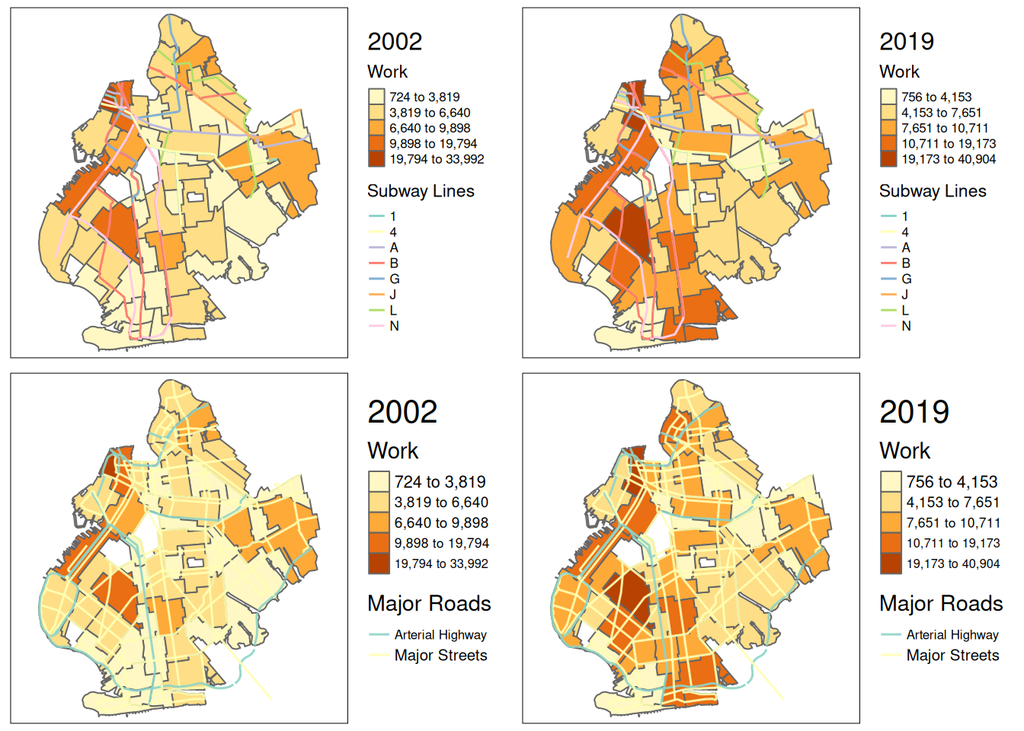

## Most popular NTAs to Live in Brooklyn across 2002 and 2019

```r
bk_origin_dist_02 <- tm_shape(bk_nta_origin_02) +
  tm_polygons(
    col = "S000",
    style = "jenks",
    title = "Home",
  ) +
  tm_layout(
    title = "2002",
    legend.outside = TRUE
  ) +
  bk_subway_lines_map

bk_origin_dist_19 <- tm_shape(bk_nta_origin_19) +
  tm_polygons(
    col = "S000",
    style = "jenks",
    title = "Home",
  ) +
  tm_layout(
    title = "2019",
    legend.outside = TRUE
  ) +
  bk_subway_lines_map

tmap_arrange(bk_origin_dist_02, bk_origin_dist_19)
```

```
## Legend labels were too wide. The labels have been resized to 0.59, 0.59, 0.59, 0.54, 0.50. Increase legend.width (argument of tm_layout) to make the legend wider and therefore the labels larger.
```

```
## Legend labels were too wide. The labels have been resized to 0.59, 0.59, 0.54, 0.50, 0.50. Increase legend.width (argument of tm_layout) to make the legend wider and therefore the labels larger.
```

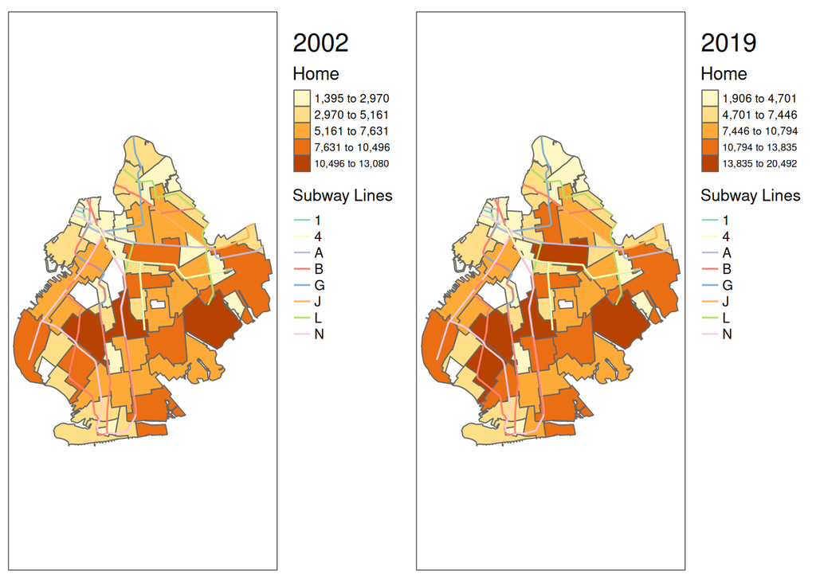

## Most popular ntas for folks to work and live within the same nta, 2002 and 2019

```r
bk_intra_nta_od_dist_02 <- tm_shape(bk_intra_nta_od_02) +
  tm_polygons(
    col = "S000",
    style = "jenks",
    title = "Count",
  ) +
  tm_layout(
    title = "2002",
    legend.outside = TRUE
  )

bk_intra_nta_od_dist_19 <- tm_shape(bk_intra_nta_od_19) +
  tm_polygons(
    col = "S000",
    style = "jenks",
    title = "Count",
  ) +
  tm_layout(
    title = "2019",
    legend.outside = TRUE
  )
bk_intra_nta_od_dist_02_sub <- bk_intra_nta_od_dist_02 + bk_subway_lines_map
bk_intra_nta_od_dist_02_road <- bk_intra_nta_od_dist_02 + bk_road_lines_map
bk_intra_nta_od_dist_19_sub <- bk_intra_nta_od_dist_19 + bk_subway_lines_map
bk_intra_nta_od_dist_19_road <- bk_intra_nta_od_dist_19 + bk_road_lines_map
tmap_arrange(
  bk_intra_nta_od_dist_02_sub,
  bk_intra_nta_od_dist_19_sub,
  bk_intra_nta_od_dist_02_road,
  bk_intra_nta_od_dist_19_road,
  ncol = 2,
  nrow = 2
)
```

```
## Some legend labels were too wide. These labels have been resized to 0.59, 0.59. Increase legend.width (argument of tm_layout) to make the legend wider and therefore the labels larger.
```

```
## Legend labels were too wide. The labels have been resized to 0.52, 0.63. Increase legend.width (argument of tm_layout) to make the legend wider and therefore the labels larger.
```

```
## Some legend labels were too wide. These labels have been resized to 0.59, 0.59, 0.59. Increase legend.width (argument of tm_layout) to make the legend wider and therefore the labels larger.
```

```
## Legend labels were too wide. The labels have been resized to 0.52, 0.63. Increase legend.width (argument of tm_layout) to make the legend wider and therefore the labels larger.
```

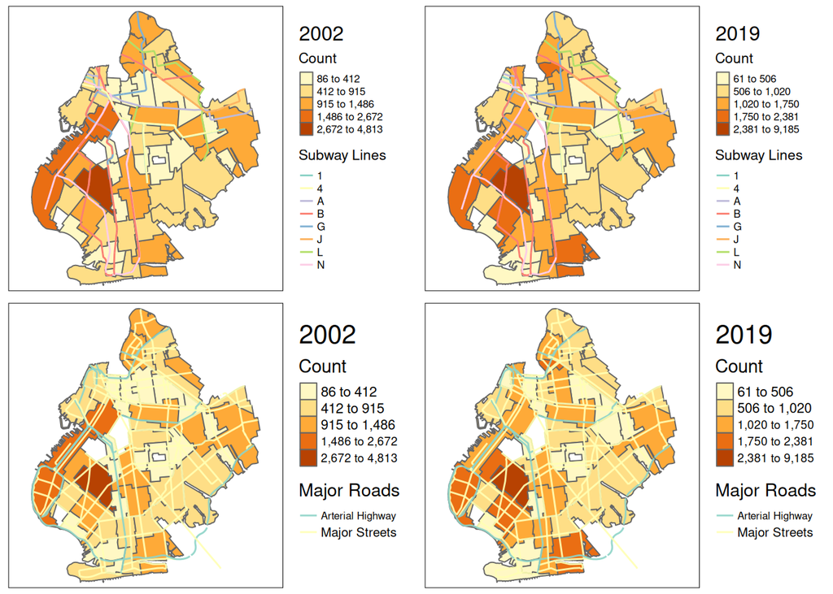

## Most popular desire lines for folks to commute from one Brooklyn NTA to another

```
## Legend labels were too wide. Therefore, legend.text.size has been set to 0.23. Increase legend.width (argument of tm_layout) to make the legend wider and therefore the labels larger.
```

```
## Legend labels were too wide. Therefore, legend.text.size has been set to 0.38. Increase legend.width (argument of tm_layout) to make the legend wider and therefore the labels larger.
```

```
## Legend labels were too wide. Therefore, legend.text.size has been set to 0.23. Increase legend.width (argument of tm_layout) to make the legend wider and therefore the labels larger.
```

```
## Legend labels were too wide. Therefore, legend.text.size has been set to 0.38. Increase legend.width (argument of tm_layout) to make the legend wider and therefore the labels larger.
```

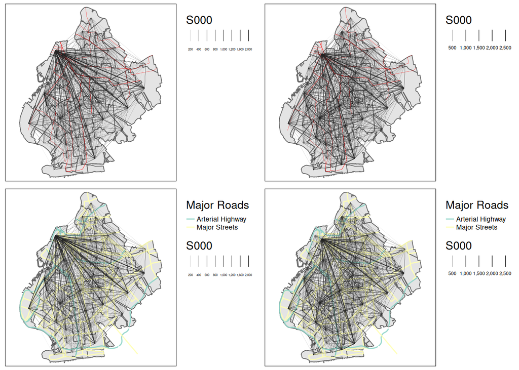

```r
bk_mono_subway_lines_map <- tm_shape(bk_subway_lines) +
  tm_lines(
    col = "#ff0000",
    lwd = 0.25,
  )

bk_desire_lines_dist_02_sub <- tm_shape(bk_nta_borders) +
  tm_polygons(
    col = "#e4e4e4",
  ) +
  bk_mono_subway_lines_map +
  tm_shape(bk_desire_lines_02) +
    tm_lines(
      col = "#212121",
      lwd = "S000",
      ) +
  tm_layout(
    legend.outside = TRUE,
    legend.text.size = 0.55,
  )

bk_desire_lines_dist_19_sub <- tm_shape(bk_nta_borders) +
  tm_polygons(
    col = "#e4e4e4",
  ) +
  bk_mono_subway_lines_map +
  tm_shape(bk_desire_lines_19) +
    tm_lines(
      col = "#212121",
      lwd = "S000",
      alpha = 0.9
      ) +
  tm_layout(
    legend.outside = TRUE,
    legend.text.size = 0.55,
  )

bk_desire_lines_dist_02_road <- tm_shape(bk_nta_borders) +
  tm_polygons(
    col = "#e4e4e4",
  ) +
  bk_road_lines_map +
  tm_shape(bk_desire_lines_02) +
    tm_lines(
      col = "#212121",
      lwd = "S000",
      ) +
  tm_layout(
    legend.outside = TRUE,
    legend.text.size = 0.55,
  )

bk_desire_lines_dist_19_road <- tm_shape(bk_nta_borders) +
  tm_polygons(
    col = "#e4e4e4",
  ) +
  bk_road_lines_map +
  tm_shape(bk_desire_lines_19) +
    tm_lines(
      col = "#212121",
      lwd = "S000",
      alpha = 0.9
      ) +
  tm_layout(
    legend.outside = TRUE,
    legend.text.size = 0.55,
  )

tmap_arrange(
  bk_desire_lines_dist_02_sub,
  bk_desire_lines_dist_19_sub,
  bk_desire_lines_dist_02_road,
  bk_desire_lines_dist_19_road,
  ncol = 2,
  nrow = 2
  )
```